# Predicting Trajectories of Agricultural Industries Using Economic Measures and Operator Demographics

Harper Lyon

https://harplyon.github.io/CMPS6790FinalTutorial/

# Guiding Questions:

The mythology of Small Farmers vs Big Ag is familiar to many Americans, but like any element of the American mythology we should be somewhat suspicious - especially when politicians and economicists claim that their new policies will help (or even "save") small farms. Today we'll be trying to get a data based answer to the question of what factors actually have an impact on the fate of the American agricultural industry, which is obviously a moderately well studied question. While we might not be able to match the quality of analysis of the USDA we can at least use their data and learn a bit about data science as we go. There are two main questions that we'll be asking:

- What measures (like Government payments to farmers, taxes, debt, etc) tell us whether an agricultural industry grows or slows in general?
- What measures tell us whether the relative share of small farmers vs big ag operations will go up or down?

To attempt to answer these questions we'll be using data both from the USDA directly and from the Agricultural Resource Management Survey, which gives us a chance to do both some classic webscraping and to use a real web API. From the USDA we'll take high quality data from the USDA census on the value of different agricultural industries in each state, and the ARMS survey will tell us more about basically any economic indicator we could ask for, but it is more limited in scope as it only covers 15 states and is inherently less reliable due to its status as a voluntary survey.

The ultimate goal is to combine this data and use it to create a linear regression model for predicting the change in agricultral productivity and farm size* over the years. From there (assuming we get an accurate model) we can extract the coefficients to analyze the relationship of each indicator in our data to both measures. The ideal outcome here is the ability to say that "In our linear model the Tax rate has a coefficient of -10, so we can see that high taxes predict low or no growth in an agricultural sector", but we've got a lot of work until we get there.

# Setup and Imports

```python
!pip3 install lxml
!pip3 install html5lib
```

```python
#General data science tools
import pandas as pd
import numpy as np
import matplotlib.pyplot as plt
import requests
import re
import functools
import seaborn as sns
from bs4 import BeautifulSoup

#sklearn imports
from sklearn.preprocessing import StandardScaler, PolynomialFeatures
from sklearn.model_selection import train_test_split
from sklearn.linear_model import LinearRegression
from sklearn.metrics import mean_squared_error

#scipy imports
import scipy.stats as stats
```

# Scraping & Cleaning

### USDA QuickStats Data:

While the USDA data we'll be using is actually downloadable in many convenient formats we'll access it via webscraping for tutorial purposes. We'll be grabbing the data from [this table](https://quickstats.nass.usda.gov/results/EA7182BD-87D0-3E47-A9C0-A9D9260F3794), which is just the results of searching for sales of by crop by state in all census years. However, while we won't be using the download data feature of the USDA website we *will* be accessing a slightly [easier to parse version of their site](https://quickstats.nass.usda.gov/data/printable/0A90D9FE-6F14-3E82-83C7-BC9FB48E126A), which is just the same table but formated for printing, so the html is a bit cleaner. Let's start by requesting the page and making some beautiful soup.

```python
# we have to trick the usda, which I hope isn't a felony
sales_request = requests.get("https://quickstats.nass.usda.gov/data/printable/0A90D9FE-6F14-3E82-83C7-BC9FB48E126A",
                headers = {'User-Agent':'Mozilla/5.0 (Macintosh; Intel Mac OS X 10.15; rv:101.0) Gecko/20100101 Firefox/101.0'})
assert sales_request.status_code == 200
```

```python
sales_soup = BeautifulSoup(sales_request.text, "html.parser")
```

And thank Uncle Sam this reads into pandas nice and cleanly.

```python
sales_df = pd.read_html(str(sales_soup.find("table")))[0]
sales_df.head()
```

|  | Program | Year | Period | Week Ending | Geo Level | State | State ANSI | Ag District | Ag District Code | County | ... | Zip Code | Region | watershed_code | Watershed | Commodity | Data Item | Domain | Domain Category | Value | CV (%) |
| --- | --- | --- | --- | --- | --- | --- | --- | --- | --- | --- | --- | --- | --- | --- | --- | --- | --- | --- | --- | --- | --- |
| 0 | CENSUS | 2017 | YEAR | NaN | STATE | ALABAMA | 1 | NaN | NaN | NaN | ... | NaN | NaN | 0 | NaN | COMMODITY TOTALS | COMMODITY TOTALS - SALES, MEASURED IN $ | NAICS CLASSIFICATION | NAICS CLASSIFICATION: (111) | 1180774000 | 2.8 |
| 1 | CENSUS | 2017 | YEAR | NaN | STATE | ALABAMA | 1 | NaN | NaN | NaN | ... | NaN | NaN | 0 | NaN | COMMODITY TOTALS | COMMODITY TOTALS - SALES, MEASURED IN $ | NAICS CLASSIFICATION | NAICS CLASSIFICATION: (1111) | 315393000 | 5.6 |
| 2 | CENSUS | 2017 | YEAR | NaN | STATE | ALABAMA | 1 | NaN | NaN | NaN | ... | NaN | NaN | 0 | NaN | COMMODITY TOTALS | COMMODITY TOTALS - SALES, MEASURED IN $ | NAICS CLASSIFICATION | NAICS CLASSIFICATION: (11111) | 62429000 | 8.6 |
| 3 | CENSUS | 2017 | YEAR | NaN | STATE | ALABAMA | 1 | NaN | NaN | NaN | ... | NaN | NaN | 0 | NaN | COMMODITY TOTALS | COMMODITY TOTALS - SALES, MEASURED IN $ | NAICS CLASSIFICATION | NAICS CLASSIFICATION: (11112) | 10000 | (H) |
| 4 | CENSUS | 2017 | YEAR | NaN | STATE | ALABAMA | 1 | NaN | NaN | NaN | ... | NaN | NaN | 0 | NaN | COMMODITY TOTALS | COMMODITY TOTALS - SALES, MEASURED IN $ | NAICS CLASSIFICATION | NAICS CLASSIFICATION: (11113) | 7000 | 55.7 |

5 rows × 21 columns

There are a few steps to cleaning here, let's start by dropping all columsn we don't need, all of which are either single valued (e.d. Period), empty (e.g. Week Ending), or essential duplicates of other columns (e.g. State ANSI). Note that this step doesn't actually remove any information from the data set - we're strictly getting rid of duplicate or empty data. Also, on a programming level, notice that we can just do this by simply grabbing the handful of columns we *do* want. This leaves us with the following data:

- Year: The year of the census this data is from.
- State: The state this data is from.
- Domain Category: The (badly titled - we'll fix that soon) NAICS classification of the crop this data represents.
- Value: The value of the crop from the state in a particular year.

```python
sales_df = sales_df.loc[:, ['Year', 'State', 'Domain Category', 'Value']]
sales_df
```

|  | Year | State | Domain Category | Value |
| --- | --- | --- | --- | --- |
| 0 | 2017 | ALABAMA | NAICS CLASSIFICATION: (111) | 1180774000 |
| 1 | 2017 | ALABAMA | NAICS CLASSIFICATION: (1111) | 315393000 |
| 2 | 2017 | ALABAMA | NAICS CLASSIFICATION: (11111) | 62429000 |
| 3 | 2017 | ALABAMA | NAICS CLASSIFICATION: (11112) | 10000 |
| 4 | 2017 | ALABAMA | NAICS CLASSIFICATION: (11113) | 7000 |
| ... | ... | ... | ... | ... |
| 9895 | 2002 | WYOMING | NAICS CLASSIFICATION: (1125) | 3210000 |
| 9896 | 2002 | WYOMING | NAICS CLASSIFICATION: (1129) | 21966000 |
| 9897 | 2002 | WYOMING | NAICS CLASSIFICATION: (11291) | 2255000 |
| 9898 | 2002 | WYOMING | NAICS CLASSIFICATION: (11292) | 10392000 |
| 9899 | 2002 | WYOMING | NAICS CLASSIFICATION: (11299) | 9318000 |

9900 rows × 4 columns

This is looking a lot more manageable, but now we have some data type/inconsistent value problems.First is that ugly Domain Category column - not only is it badly named, it's also in a pretty ugly format. Let's create a new column and extraxt the actual classification value from each row, then drop the original column.

```python
sales_df.loc[:, 'NAICS'] = [re.findall(r"\d+", s)[0] for s in sales_df['Domain Category']]
sales_df.drop(['Domain Category'], axis=1, inplace=True)
sales_df
```

|  | Year | State | Value | NAICS |
| --- | --- | --- | --- | --- |
| 0 | 2017 | ALABAMA | 1180774000 | 111 |
| 1 | 2017 | ALABAMA | 315393000 | 1111 |
| 2 | 2017 | ALABAMA | 62429000 | 11111 |
| 3 | 2017 | ALABAMA | 10000 | 11112 |
| 4 | 2017 | ALABAMA | 7000 | 11113 |
| ... | ... | ... | ... | ... |
| 9895 | 2002 | WYOMING | 3210000 | 1125 |
| 9896 | 2002 | WYOMING | 21966000 | 1129 |
| 9897 | 2002 | WYOMING | 2255000 | 11291 |
| 9898 | 2002 | WYOMING | 10392000 | 11292 |
| 9899 | 2002 | WYOMING | 9318000 | 11299 |

9900 rows × 4 columns

So, we now have the data we actually care about for this column, but it's still not perfect - what even is an NAICS class? Well NAICS is simply a set of codes that the government uses to denote specific industries. Anything that starts with 11 is Agriculture, 111 is crops (vegetable, fruits, ect), 112 livestock, etc. This goes on to very high level of specificity, for instance 111110 is Soybeans, and 111120 is non-soybean oilbeans. The real question of this data cleaning stage is how to handle NAICS - we could compress everything to fairly high level categories (say 4 digits, this would be on the level of Grain, Vegetable, Hog, Cattle, etc) and drop all other data - this has the advantage of reducing the size of our dataset and being easy to translate NAICS codes. We could also translate each individual NAICS code to get a more granular break down. Eventually we'll want to do the later, but handling each code is a lot of work - for the purposes of exploration let's just translate the four digit codes and create a condensed dataframe.

```python
sales_df = sales_df.loc[[len(code) == 4 for code in sales_df['NAICS']]].copy()
sales_df.reset_index(inplace=True)
```

Now we can create a new column for the meanings of the codes, which for now we'll convert manually with a dictionary.

```python
naics_dict = {
    '1111' : 'Oilseed and Grain',
    '1112' : 'Vegetable and Melon',
    '1113' : 'Fruit and Tree Nut',
    '1114' : 'Greenhouse, Nursery, and Floriculture',
    '1119' : 'Other Crops',
    '1121' : 'Cattle',
    '1122' : 'Hog',
    '1123' : 'Poultry',
    '1124' : 'Sheep and Goat',
    '1125' : 'Aquaculture',
    '1129' : 'Other Animals'
}

sales_df.loc[:, 'Category'] = [naics_dict[code] for code in sales_df['NAICS']]
print(sales_df.dtypes)
sales_df
```

```
index        int64
Year         int64
State       object
Value       object
NAICS       object
Category    object
dtype: object
```

|  | index | Year | State | Value | NAICS | Category |
| --- | --- | --- | --- | --- | --- | --- |
| 0 | 1 | 2017 | ALABAMA | 315393000 | 1111 | Oilseed and Grain |
| 1 | 8 | 2017 | ALABAMA | 53633000 | 1112 | Vegetable and Melon |
| 2 | 11 | 2017 | ALABAMA | 16156000 | 1113 | Fruit and Tree Nut |
| 3 | 22 | 2017 | ALABAMA | 295784000 | 1114 | Greenhouse, Nursery, and Floriculture |
| 4 | 27 | 2017 | ALABAMA | 499808000 | 1119 | Other Crops |
| ... | ... | ... | ... | ... | ... | ... |
| 2295 | 9888 | 2002 | WYOMING | 22536000 | 1122 | Hog |
| 2296 | 9889 | 2002 | WYOMING | 546000 | 1123 | Poultry |
| 2297 | 9892 | 2002 | WYOMING | 25076000 | 1124 | Sheep and Goat |
| 2298 | 9895 | 2002 | WYOMING | 3210000 | 1125 | Aquaculture |
| 2299 | 9896 | 2002 | WYOMING | 21966000 | 1129 | Other Animals |

2300 rows × 6 columns

With this we're almost done, just have to deal with the typing on the Value column - currently that's strings because of some "(D)" values. In the dataset that means that the USDA isn't publishing the data because it would compromise the details of an operation - usually because there's only one, say, citrus orchard in Alaska. We got rid of most of those when we compressed the dataset into just the major categories, but there are still a few. We'll replace those with NaN - this might not be the best approach if we wanted to do real predictive work, but for exploration purposes it's fine.

```python
sales_df['Value'] = [float(val) if val != '(D)' else np.nan for val in sales_df['Value']]
sales_df.dtypes
```

```
index         int64
Year          int64
State        object
Value       float64
NAICS        object
Category     object
dtype: object
```

### Agricultural Resource Management Survey Data

If we want to do anything more interesting than look at sales we need to know more about the ways that farms are operating which leads us to ARMS, a massive survey run each year to gather data on Farmer income, expenses, demographics, and many other categories of information. We'll specifically be accessing information on government support of farms (in the form of direct payments, favorable loans, etc.) and the average taxes paid by farms - again all broken down by state and industry. This data is accessed through a RESTFUL API, so we'll be using the python requests library in a slightly more advanced way. The instructions and information for the ARMS API is all available at [this website](https://www.ers.usda.gov/developer/data-apis/arms-data-api/). Let's start by making requests for the following information sets:

- Total payments from government programs to farms per state per industry.
- Average gross taxes paid by farms per state per industry.
- The Average Cost to Dept ratio for each farm.
- Average Liabilities (debt) for each farm.
- Average Labor Cost per farm.
- Average Gross Income per farm.
- Percentage of Operators who own the entirety of their farm.
- Percentage of Operators who partially own their farms (think someone who owns their home and part of the land they farm but rents additional acreage)
- Percentage of Operators who are purely renters, and are therefore essentially tenant farmers.
- Percentage of Operators who have a college degree.
- Percentage of Operators who don't have a high school diploma.

Note that one of these values is more important than the others - the average gross income per farm. This value is especially important to our analysis because we're going to use it as a proxy for farm size. Obtaining good data on the relative farm size in each industry/state has proven quite difficult, so we're going to focus on average income with the rationale that high average income means that the average farm is big, and low means the average farm is small. This is obviously an imperfect metric, but it's the best I've found so far.

```python
# store my personal api key for easy use
api_key = "mxBy9mHz74LQcxQk5MsSkVapoTAJ6R3yy0uo6uER"

# define the years we're interested in (the same as present in the USDA census) and ask the API for the available states
years = ['2002', '2007', '2012', '2017']
states = [d['name'] for d in requests.get("https://api.ers.usda.gov/data/arms/state?api_key=" + api_key).json()['data'][1:]]

# here we make the requests - each is a .get to a specific URL which includes my key, the years and states we're interested in, as well as the variable code and the category breakdowns
payments = requests.get("https://api.ers.usda.gov/data/arms/surveydata?api_key=" + api_key + "&year=" + ','.join(years) + "&state=" + ','.join(states) + "&variable=igovtt&category=spec")
taxes = requests.get("https://api.ers.usda.gov/data/arms/surveydata?api_key=" + api_key + "&year=" + ','.join(years) + "&state=" + ','.join(states) + "&variable=eftaxes&category=spec")
cost_ratio = requests.get("https://api.ers.usda.gov/data/arms/surveydata?api_key=" + api_key + "&year=" + ','.join(years) + "&state=" + ','.join(states) + "&variable=freconum&category=spec")
liabilities = requests.get("https://api.ers.usda.gov/data/arms/surveydata?api_key=" + api_key + "&year=" + ','.join(years) + "&state=" + ','.join(states) + "&variable=dtot&category=spec")

labor_cost = requests.get("https://api.ers.usda.gov/data/arms/surveydata?api_key=" + api_key + "&year=" + ','.join(years) + "&state=" + ','.join(states) + "&variable=evlabor&category=spec")
avg_gross = requests.get("https://api.ers.usda.gov/data/arms/surveydata?api_key=" + api_key + "&year=" + ','.join(years) + "&state=" + ','.join(states) + "&variable=igcfioth&category=spec")
profit_margin = requests.get("https://api.ers.usda.gov/data/arms/surveydata?api_key=" + api_key + "&year=" + ','.join(years) + "&state=" + ','.join(states) + "&variable=fropmnum&category=spec")
inventory_change = requests.get("https://api.ers.usda.gov/data/arms/surveydata?api_key=" + api_key + "&year=" + ','.join(years) + "&state=" + ','.join(states) + "&variable=ivalinv&category=spec")
owners = requests.get("https://api.ers.usda.gov/data/arms/surveydata?api_key=" + api_key + "&year=" + ','.join(years) + "&state=" + ','.join(states) + "&variable=ten1&category=spec")
part_owners = requests.get("https://api.ers.usda.gov/data/arms/surveydata?api_key=" + api_key + "&year=" + ','.join(years) + "&state=" + ','.join(states) + "&variable=ten2&category=spec")
renters = requests.get("https://api.ers.usda.gov/data/arms/surveydata?api_key=" + api_key + "&year=" + ','.join(years) + "&state=" + ','.join(states) + "&variable=ten3&category=spec")
no_high_school = requests.get("https://api.ers.usda.gov/data/arms/surveydata?api_key=" + api_key + "&year=" + ','.join(years) + "&state=" + ','.join(states) + "&variable=oped1&category=spec")
college = requests.get("https://api.ers.usda.gov/data/arms/surveydata?api_key=" + api_key + "&year=" + ','.join(years) + "&state=" + ','.join(states) + "&variable=oped4&category=spec")
```

Each of these requests gives us a json object, which contains a few bits of request information (status, time, record count, etc), but also all of the data. We can feed those into pandas to generate a dataframe:

```python
payments_df = pd.DataFrame(payments.json()['data'])
taxes_df = pd.DataFrame(taxes.json()['data'])
cost_ratio_df = pd.DataFrame(cost_ratio.json()['data'])
liabilities_df = pd.DataFrame(liabilities.json()['data'])
labor_cost_df = pd.DataFrame(labor_cost.json()['data'])
avg_gross_df = pd.DataFrame(avg_gross.json()['data'])
inventory_change_df = pd.DataFrame(inventory_change.json()['data'])
owners_df = pd.DataFrame(owners.json()['data'])
part_owners_df = pd.DataFrame(part_owners.json()['data'])
renters_df = pd.DataFrame(renters.json()['data'])
no_high_school_df = pd.DataFrame(no_high_school.json()['data'])
college_df = pd.DataFrame(college.json()['data'])

payments_df
```

|  | year | state | report | farmtype | category | category_value | category2 | category2_value | variable_id | variable_name | ... | variable_group_id | variable_unit | variable_description | variable_is_invalid | estimate | median | statistic | rse | unreliable_estimate | decimal_display |
| --- | --- | --- | --- | --- | --- | --- | --- | --- | --- | --- | --- | --- | --- | --- | --- | --- | --- | --- | --- | --- | --- |
| 0 | 2007 | Arkansas | Government Payments | All Farms | Production Specialty | Wheat | All Farms | TOTAL | igovtt | All government payments | ... | 5 | 1,000 Dollars | Total government payments include direct payme... | False | NaN | None | TOTAL | NaN | 0 | 0 |
| 1 | 2007 | Arkansas | Government Payments | All Farms | Production Specialty | Soybean | All Farms | TOTAL | igovtt | All government payments | ... | 5 | 1,000 Dollars | Total government payments include direct payme... | False | 45305.0 | None | TOTAL | 21.2 | 0 | 0 |
| 2 | 2007 | Arkansas | Government Payments | All Farms | Production Specialty | Tobacco, Cotton, Peanuts | All Farms | TOTAL | igovtt | All government payments | ... | 5 | 1,000 Dollars | Total government payments include direct payme... | False | 40169.0 | None | TOTAL | 19.1 | 0 | 0 |
| 3 | 2007 | Arkansas | Government Payments | All Farms | Production Specialty | Hogs | All Farms | TOTAL | igovtt | All government payments | ... | 5 | 1,000 Dollars | Total government payments include direct payme... | False | 0.0 | None | TOTAL | NaN | 0 | 0 |
| 4 | 2007 | Arkansas | Government Payments | All Farms | Production Specialty | Poultry | All Farms | TOTAL | igovtt | All government payments | ... | 5 | 1,000 Dollars | Total government payments include direct payme... | False | 1610.0 | None | TOTAL | 43.5 | 0 | 0 |
| ... | ... | ... | ... | ... | ... | ... | ... | ... | ... | ... | ... | ... | ... | ... | ... | ... | ... | ... | ... | ... | ... |
| 491 | 2017 | Wisconsin | Government Payments | All Farms | Production Specialty | Wheat | All Farms | TOTAL | igovtt | All government payments | ... | 5 | 1,000 Dollars | Total government payments include direct payme... | False | NaN | None | TOTAL | NaN | 0 | 0 |
| 492 | 2017 | Wisconsin | Government Payments | All Farms | Production Specialty | Soybean | All Farms | TOTAL | igovtt | All government payments | ... | 5 | 1,000 Dollars | Total government payments include direct payme... | False | 11466.0 | None | TOTAL | 37.4 | 0 | 0 |
| 493 | 2017 | Wisconsin | Government Payments | All Farms | Production Specialty | Specialty Crops (F,V,N) | All Farms | TOTAL | igovtt | All government payments | ... | 5 | 1,000 Dollars | Total government payments include direct payme... | False | 3776.0 | None | TOTAL | 38.0 | 0 | 0 |
| 494 | 2017 | Wisconsin | Government Payments | All Farms | Production Specialty | Cattle | All Farms | TOTAL | igovtt | All government payments | ... | 5 | 1,000 Dollars | Total government payments include direct payme... | False | 11262.0 | None | TOTAL | 31.3 | 0 | 0 |
| 495 | 2017 | Wisconsin | Government Payments | All Farms | Production Specialty | Poultry | All Farms | TOTAL | igovtt | All government payments | ... | 5 | 1,000 Dollars | Total government payments include direct payme... | False | 645.0 | None | TOTAL | 79.0 | 0 | 0 |

496 rows × 23 columns

As you can probably tell from the peek into the payments data above, this data has way to many columns, including many which just explain the values found in other columns. Let's go ahead and grab only the columns we care about for each frame - the year, state, category_value, and "estimate", which is ARMS name for the value (they're just hedging their language based on the fact that this is a survey - which we should keep in mind as well).

```python
# While dropping out the columns we don't care about we're going to also rename the columns to match those in the USDA data
payments_df = payments_df.loc[:, ['year', 'state', 'category_value', 'estimate']].rename(columns={'year':'Year', 'state':'State', 'category_value':'Category', 'estimate':'Payments'})
taxes_df = taxes_df.loc[:, ['year', 'state', 'category_value', 'estimate']].rename(columns={'year':'Year', 'state':'State', 'category_value':'Category', 'estimate':'Taxes'})
cost_ratio_df = cost_ratio_df.loc[:, ['year', 'state', 'category_value', 'estimate']].rename(columns={'year':'Year', 'state':'State', 'category_value':'Category', 'estimate':'Cost Income Ratio'})
liabilities_df = liabilities_df.loc[:, ['year', 'state', 'category_value', 'estimate']].rename(columns={'year':'Year', 'state':'State', 'category_value':'Category', 'estimate':'Liability'})
labor_cost_df = labor_cost_df.loc[:, ['year', 'state', 'category_value', 'estimate']].rename(columns={'year':'Year', 'state':'State', 'category_value':'Category', 'estimate':'Labor'})
avg_gross_df = avg_gross_df.loc[:, ['year', 'state', 'category_value', 'estimate']].rename(columns={'year':'Year', 'state':'State', 'category_value':'Category', 'estimate':'Avg Gross'})
inventory_change_df = inventory_change_df.loc[:, ['year', 'state', 'category_value', 'estimate']].rename(columns={'year':'Year', 'state':'State', 'category_value':'Category', 'estimate':'Inventory Change'})
owners_df = owners_df.loc[:, ['year', 'state', 'category_value', 'estimate']].rename(columns={'year':'Year', 'state':'State', 'category_value':'Category', 'estimate':'Full Owners'})
part_owners_df = part_owners_df.loc[:, ['year', 'state', 'category_value', 'estimate']].rename(columns={'year':'Year', 'state':'State', 'category_value':'Category', 'estimate':'Part Owners'})
renters_df = renters_df.loc[:, ['year', 'state', 'category_value', 'estimate']].rename(columns={'year':'Year', 'state':'State', 'category_value':'Category', 'estimate':'Renters'})
no_high_school_df = no_high_school_df.loc[:, ['year', 'state', 'category_value', 'estimate']].rename(columns={'year':'Year', 'state':'State', 'category_value':'Category', 'estimate':'No High School'})
college_df = college_df.loc[:, ['year', 'state', 'category_value', 'estimate']].rename(columns={'year':'Year', 'state':'State', 'category_value':'Category', 'estimate':'College Graduates'})


payments_df
```

|  | Year | State | Category | Payments |
| --- | --- | --- | --- | --- |
| 0 | 2007 | Arkansas | Wheat | NaN |
| 1 | 2007 | Arkansas | Soybean | 45305.0 |
| 2 | 2007 | Arkansas | Tobacco, Cotton, Peanuts | 40169.0 |
| 3 | 2007 | Arkansas | Hogs | 0.0 |
| 4 | 2007 | Arkansas | Poultry | 1610.0 |
| ... | ... | ... | ... | ... |
| 491 | 2017 | Wisconsin | Wheat | NaN |
| 492 | 2017 | Wisconsin | Soybean | 11466.0 |
| 493 | 2017 | Wisconsin | Specialty Crops (F,V,N) | 3776.0 |
| 494 | 2017 | Wisconsin | Cattle | 11262.0 |
| 495 | 2017 | Wisconsin | Poultry | 645.0 |

496 rows × 4 columns

We're going to do some additional processing here, but first we can join these requests so that we can stop keeping track of multiple dataframes.

```python
# We'll package all the requests into a list so we can iterattively merge
all_requests = [payments_df, taxes_df, cost_ratio_df, liabilities_df, labor_cost_df, avg_gross_df, inventory_change_df, owners_df, part_owners_df, renters_df, no_high_school_df, college_df]

#Our data isn't really big enough to make using reduce a large advantage here, but if we had either more rows or more frames we would see a large difference in speed
survey_df = functools.reduce(lambda a, b : pd.merge(a, b, on=['Year', 'State', 'Category'], how='outer'), all_requests)
```

Alright we're down to one frame now. First thing we need to do is get the Payments column into full dollar values (as it is in sales), which is just a matter of multiplying all values by 1000. All the other columns already operate in dollars (or dollars / farm), so it isn't clear why only government payments are measured in thousands. Just goes to show you should always be careful about units. Of course, it won't matter much once we standardize all these values, but until then it's good to have consistent units.

```python
survey_df['Payments'] = survey_df['Payments'].map(lambda x : x * 1000)
```

```python
survey_df
```

|  | Year | State | Category | Payments | Taxes | Cost Income Ratio | Liability | Labor | Avg Gross | Inventory Change | Full Owners | Part Owners | Renters | No High School | College Graduates |
| --- | --- | --- | --- | --- | --- | --- | --- | --- | --- | --- | --- | --- | --- | --- | --- |
| 0 | 2007 | Arkansas | Wheat | NaN | NaN | NaN | NaN | NaN | NaN | NaN | NaN | NaN | NaN | NaN | NaN |
| 1 | 2007 | Arkansas | Wheat | NaN | NaN | NaN | NaN | NaN | NaN | NaN | NaN | NaN | NaN | NaN | NaN |
| 2 | 2007 | Arkansas | Soybean | 45305000.0 | 2204.0 | 105.2 | 103849.0 | 39332.0 | 1152896.0 | -12364.0 | 23.0 | 54.7 | 22.3 | 5.8 | 23.3 |
| 3 | 2007 | Arkansas | Soybean | 45305000.0 | 2204.0 | 105.2 | 103849.0 | 39332.0 | 1152896.0 | -12364.0 | 23.0 | 54.7 | 22.3 | 5.8 | 23.3 |
| 4 | 2007 | Arkansas | Tobacco, Cotton, Peanuts | 40169000.0 | 3257.0 | 110.6 | 166586.0 | 60308.0 | 3536189.0 | 18547.0 | 0.7 | 34.0 | 65.3 | 4.0 | 13.4 |
| ... | ... | ... | ... | ... | ... | ... | ... | ... | ... | ... | ... | ... | ... | ... | ... |
| 987 | 2017 | Wisconsin | Specialty Crops (F,V,N) | 3776000.0 | 4971.0 | 113.9 | 160202.0 | 55905.0 | 631581.0 | 2749.0 | 64.6 | 24.0 | 11.4 | 6.4 | 38.4 |
| 988 | 2017 | Wisconsin | Cattle | 11262000.0 | 3655.0 | 144.6 | 79811.0 | 1194.0 | 61544.0 | 3494.0 | 78.7 | 20.0 | 1.3 | 7.6 | 11.9 |
| 989 | 2017 | Wisconsin | Cattle | 11262000.0 | 3655.0 | 144.6 | 79811.0 | 1194.0 | 61544.0 | 3494.0 | 78.7 | 20.0 | 1.3 | 7.6 | 11.9 |
| 990 | 2017 | Wisconsin | Poultry | 645000.0 | 3223.0 | 128.7 | 74358.0 | 5507.0 | NaN | 1727.0 | 97.6 | 2.4 | 0.0 | 6.8 | 36.6 |
| 991 | 2017 | Wisconsin | Poultry | 645000.0 | 3223.0 | 128.7 | 74358.0 | 5507.0 | NaN | 1727.0 | 97.6 | 2.4 | 0.0 | 6.8 | 36.6 |

992 rows × 15 columns

# Joining

We now need to combine these two datasets, which means deciding which columns (if any) we'll be matching and making sure they're ready to match up. In this case we're going to match on three values - year, state, and category. We're going to focus on changing the survey data to match the sales data - though we could easily choose to do the reverse. Some of these edits are easy, year already matches and state is just a matter of capitalization, but matching categories is harder. Let's perform that easy change and take a closer look at the two category value sets.

```python
# changing state format to match sales data
survey_df['State'] = survey_df['State'].map(lambda x : x.upper())

print("Categories in USDA sales data: ", sales_df['Category'].unique())
print()
print("Categories in ARMS data: ", survey_df['Category'].unique())
```

```
Categories in USDA sales data:  ['Oilseed and Grain' 'Vegetable and Melon' 'Fruit and Tree Nut'
 'Greenhouse, Nursery, and Floriculture' 'Other Crops' 'Cattle' 'Hog'
 'Poultry' 'Sheep and Goat' 'Aquaculture' 'Other Animals']

Categories in ARMS data:  ['Wheat' 'Soybean' 'Tobacco, Cotton, Peanuts' 'Hogs' 'Poultry' 'Dairy'
 'General Cash Grains' 'Cattle' 'Specialty Crops (F,V,N)'
 'All other livestock' 'Corn' 'Other Field Crops']
```

Here we need to make some decisions on how to match up these categories. Below is how I'll be mapping each category that doesn't have a clear 1-1 mapping (i.e. Hogs to Hog):

- General Cash Grains, Wheat, Corn, Soybean -> Oilseed and Grain
- Other Field Crops, Tobacco, Cotton, Peanuts -> Other Crops
- Dairy -> Cattle

This leaves us with the categories 'All other livestock' and 'Specialty Crops (F, V, N)' (stands for Fruit, Vegetable, Nut), which have the problem of spanning multiple categories in the USDA dataset. Since we have no way of dividing these, we have a two real choices - we can drop the entries entirely, leading to us having no data to augment those categories in the sales data (note that this is already going to happen to Aquaculture which is not included in the survey) or we can combine the categories in the USDA data (e.g. merge Vegetable and Melon, Fruit and Tree Nut, and Greenhouse, Nursery, and Floriculture'). Let's make an informed decision - how much data would we be losing or combining?

```python
specialty_count = sales_df[sales_df['Category'].isin(['Vegetable and Melon', 'Fruit and Tree Nut', 'Greenhouse, Nursery, and Floriculture'])].shape[0]
print(f"There are {specialty_count} observations which would be in the new Specialty Crops category, or {(specialty_count / sales_df.shape[0]) * 100 :.2f}%" )
animal_count = sales_df[sales_df['Category'].isin(['Other Animals', 'Sheep and Goat'])].shape[0]
print(f"There are {animal_count} observations which would be in the new Other Animals category, or {(animal_count / sales_df.shape[0]) * 100 :.2f}%")
```

```
There are 600 observations which would be in the new Specialty Crops category, or 26.09%
There are 400 observations which would be in the new Other Animals category, or 17.39%
```

That's a fair bit of data to merge, given that we have a total of 2300 observations - but hold up, we know we're going to be dropping several states from the analysis already, do our numbers improve there?

```python
#we can reach back and use the list of states we requested from the ERS in the scraping step
states_filtered = sales_df[sales_df['State'].isin([s.upper() for s in states])]
print(f"By filtering states not present in the ARMS survey data we removed {sales_df.shape[0] - states_filtered.shape[0]} entries, leading to new merging considerations below:")

specialty_count = states_filtered[states_filtered['Category'].isin(['Vegetable and Melon', 'Fruit and Tree Nut', 'Greenhouse, Nursery, and Floriculture'])].shape[0]
print(f"There are {specialty_count} observations which would be in the new Specialty Crops category, or {(specialty_count / states_filtered.shape[0]) * 100 :.2f}%" )
animal_count = states_filtered[states_filtered['Category'].isin(['Other Animals', 'Sheep and Goat'])].shape[0]
print(f"There are {animal_count} observations which would be in the new Other Animals category, or {(animal_count / states_filtered.shape[0]) * 100 :.2f}%")
```

```
By filtering states not present in the ARMS survey data we removed 1610 entries, leading to new merging considerations below:
There are 180 observations which would be in the new Specialty Crops category, or 26.09%
There are 120 observations which would be in the new Other Animals category, or 17.39%
```

Turns out when you're dealing with an fundamentally combinatorial dataset (there is one and only one entry for each possibility of year, state, and category in the sales data), you're not going to get a better deal with a smaller dataset. I think this is a reasonable merge to perform, as the alternative is to drop more than a third of our total data which I'm just not willing to do at this stage. Hopefully the ARMS folks were onto something by grouping together these categories. So we now have to perform transformations on both frames to prepare for the merge - we have to translate then merge (via groupby) the various categories in both sales_df and survey_df.

```python
#Translation scheme for sales data categories
sales_translation = {'Vegetable and Melon' : 'Specialty Crop', 'Fruit and Tree Nut' : 'Specialty Crop', 'Greenhouse, Nursery, and Floriculture' : 'Specialty Crop',
                     'Sheep and Goat' : 'Other Animals'}

#Applying translation and merging the new categories into each other
sales_df['Category'] = sales_df['Category'].map(lambda x : sales_translation.get(x, x))
sales_df = sales_df.groupby(['Year', 'State', 'Category'])['Value'].sum().reset_index()
```

That's the sales data done - pretty straightforward. The survey data is a bit trickier because we're translating more categories and also have to be merge more variables for the final data. Pay particular attention to how we aggregate different values differently - total values like Payments get summed, while average or per farm columns (pretty much everything else) gets averaged (since it doesn't really make sense to just add averages together).

```python
survey_df.head()
```

|  | Year | State | Category | Payments | Taxes | Cost Income Ratio | Liability | Labor | Avg Gross | Inventory Change | Full Owners | Part Owners | Renters | No High School | College Graduates |
| --- | --- | --- | --- | --- | --- | --- | --- | --- | --- | --- | --- | --- | --- | --- | --- |
| 0 | 2007 | ARKANSAS | Wheat | NaN | NaN | NaN | NaN | NaN | NaN | NaN | NaN | NaN | NaN | NaN | NaN |
| 1 | 2007 | ARKANSAS | Wheat | NaN | NaN | NaN | NaN | NaN | NaN | NaN | NaN | NaN | NaN | NaN | NaN |
| 2 | 2007 | ARKANSAS | Soybean | 45305000.0 | 2204.0 | 105.2 | 103849.0 | 39332.0 | 1152896.0 | -12364.0 | 23.0 | 54.7 | 22.3 | 5.8 | 23.3 |
| 3 | 2007 | ARKANSAS | Soybean | 45305000.0 | 2204.0 | 105.2 | 103849.0 | 39332.0 | 1152896.0 | -12364.0 | 23.0 | 54.7 | 22.3 | 5.8 | 23.3 |
| 4 | 2007 | ARKANSAS | Tobacco, Cotton, Peanuts | 40169000.0 | 3257.0 | 110.6 | 166586.0 | 60308.0 | 3536189.0 | 18547.0 | 0.7 | 34.0 | 65.3 | 4.0 | 13.4 |

```python
#Because of the high degree of redundancy in the translations a function is prefered to a dictionary here
def translate_survey_category(cat):
    if cat in ['General Cash Grains', 'Wheat', 'Corn', 'Soybean']:
        return 'Oilseed and Grain'
    if cat in ['Other Field Crops', 'Tobacco, Cotton, Peanuts']:
        return 'Other Crops'
    if cat in ['Cattle', 'Dairy']:
        return 'Cattle'
    if cat == 'Hogs':
        return 'Hog'
    if cat == 'Specialty Crops (F,V,N)':
        return 'Specialty Crop'
    if cat == 'All other livestock':
        return 'Other Animals'
    return cat

#translating categories
survey_df['Category'] = survey_df['Category'].map(translate_survey_category)
#merging newly matched rows - we need to be careful to apply the correct kind of merge as we don't to sum averages
survey_df = survey_df.groupby(['Year', 'State', 'Category']).agg({'Payments' : 'sum', 'Taxes' : 'mean', 'Cost Income Ratio' : 'mean', 'Liability' : 'mean', 'Labor' : 'mean', 'Avg Gross' : np.mean,
                                                                  'Full Owners' : 'mean', 'Part Owners' : 'mean', 'Renters' : 'mean', 'No High School' : 'mean', 'College Graduates' : 'mean'}).reset_index()
survey_df
```

|  | Year | State | Category | Payments | Taxes | Cost Income Ratio | Liability | Labor | Avg Gross | Full Owners | Part Owners | Renters | No High School | College Graduates |
| --- | --- | --- | --- | --- | --- | --- | --- | --- | --- | --- | --- | --- | --- | --- |
| 0 | 2007 | ARKANSAS | Cattle | 23552000.0 | 1123.000000 | 241.200000 | 21327.000000 | 1503.000000 | 2.909900e+04 | 60.300000 | 35.100000 | 4.700000 | 7.800000 | 18.300000 |
| 1 | 2007 | ARKANSAS | Hog | 0.0 | 1442.000000 | 89.200000 | 43809.000000 | 13510.000000 | NaN | 57.200000 | 42.800000 | 0.000000 | 0.000000 | 20.600000 |
| 2 | 2007 | ARKANSAS | Oilseed and Grain | 407102000.0 | 2877.000000 | 106.933333 | 222385.000000 | 46342.666667 | 1.578508e+06 | 16.266667 | 47.800000 | 35.866667 | 2.633333 | 36.800000 |
| 3 | 2007 | ARKANSAS | Other Animals | 2198000.0 | 996.000000 | 469.100000 | 43730.000000 | 3752.000000 | 2.052870e+05 | 83.300000 | 14.300000 | 2.400000 | 8.500000 | 7.900000 |
| 4 | 2007 | ARKANSAS | Other Crops | 96538000.0 | 2202.500000 | 174.500000 | 91809.000000 | 30273.500000 | 3.536189e+06 | 45.750000 | 21.550000 | 32.700000 | 2.250000 | 27.750000 |
| ... | ... | ... | ... | ... | ... | ... | ... | ... | ... | ... | ... | ... | ... | ... |
| 309 | 2017 | WISCONSIN | Oilseed and Grain | 109740000.0 | 5631.666667 | 125.900000 | 170874.666667 | 6120.666667 | 1.517163e+05 | 40.566667 | 54.066667 | 5.366667 | 3.433333 | 23.966667 |
| 310 | 2017 | WISCONSIN | Other Animals | 6198000.0 | 3283.000000 | 250.800000 | 91014.000000 | 2588.000000 | NaN | 72.700000 | 15.300000 | 12.000000 | 7.700000 | 47.500000 |
| 311 | 2017 | WISCONSIN | Other Crops | 62090000.0 | 4026.000000 | 179.500000 | 58858.000000 | 3117.000000 | 1.883500e+04 | 85.200000 | 12.600000 | 2.200000 | 3.800000 | 33.400000 |
| 312 | 2017 | WISCONSIN | Poultry | 1290000.0 | 3223.000000 | 128.700000 | 74358.000000 | 5507.000000 | NaN | 97.600000 | 2.400000 | 0.000000 | 6.800000 | 36.600000 |
| 313 | 2017 | WISCONSIN | Specialty Crop | 7552000.0 | 4971.000000 | 113.900000 | 160202.000000 | 55905.000000 | 6.315810e+05 | 64.600000 | 24.000000 | 11.400000 | 6.400000 | 38.400000 |

314 rows × 14 columns

We now have two compatible dataframes which are ready to merge. We're going to do an inner merge here to drop any entries in the sales data that don't have matching survey data, since we need a complete observations to do any sort of real analysis.

```python
# Note this is essentially the same code as we used to merge the survey data originally
ag_df = pd.merge(sales_df, survey_df, on=['Year', 'State', 'Category'], how='inner')
ag_df.head()
```

|  | Year | State | Category | Value | Payments | Taxes | Cost Income Ratio | Liability | Labor | Avg Gross | Full Owners | Part Owners | Renters | No High School | College Graduates |
| --- | --- | --- | --- | --- | --- | --- | --- | --- | --- | --- | --- | --- | --- | --- | --- |
| 0 | 2007 | ARKANSAS | Cattle | 5.969890e+08 | 23552000.0 | 1123.0 | 241.200000 | 21327.0 | 1503.000000 | 29099.0 | 60.300000 | 35.10 | 4.700000 | 7.800000 | 18.30 |
| 1 | 2007 | ARKANSAS | Hog | 7.903800e+07 | 0.0 | 1442.0 | 89.200000 | 43809.0 | 13510.000000 | NaN | 57.200000 | 42.80 | 0.000000 | 0.000000 | 20.60 |
| 2 | 2007 | ARKANSAS | Oilseed and Grain | 2.273703e+09 | 407102000.0 | 2877.0 | 106.933333 | 222385.0 | 46342.666667 | 1578508.5 | 16.266667 | 47.80 | 35.866667 | 2.633333 | 36.80 |
| 3 | 2007 | ARKANSAS | Other Animals | 1.854300e+07 | 2198000.0 | 996.0 | 469.100000 | 43730.0 | 3752.000000 | 205287.0 | 83.300000 | 14.30 | 2.400000 | 8.500000 | 7.90 |
| 4 | 2007 | ARKANSAS | Other Crops | 5.201590e+08 | 96538000.0 | 2202.5 | 174.500000 | 91809.0 | 30273.500000 | 3536189.0 | 45.750000 | 21.55 | 32.700000 | 2.250000 | 27.75 |

Now we don't have to do a ton more processing, but there are a few variables we should scale. In particular the taxes, labor costs, and liabilities need to be scaled by farm income, as otherwise we're going to end up secretly including target data in our variables. Consider that larger farms will pay more in labor and more in taxes and can safely have more debt, and that this isn't all that interesting - what we really care about is *tax rate*, how much an industry is paying for labor relative to income, and how bad the average debt to income ratio is.

```python
ag_df['Taxes'] = ag_df['Taxes'] / ag_df['Avg Gross']
ag_df['Labor'] = ag_df['Labor'] / ag_df['Avg Gross']
ag_df['Liability'] = ag_df['Liability'] / ag_df['Avg Gross']
```

# Exploratory Analysis

We now have about 300 instances of data which range over fifteen states and cover a variety of measurements. However, to answer our two main questions - which both cover changes from one census year to the other - we need to do some comparative measurements. That's why the first step in our model prep is to add two new values to each observation from 2007 and 2012 - the change in both total value and avg gross income. This is a little bit tricky, so we're going to write a function to take care of it:

```python
def calc_change_in_values(row, df):
    #first we have to check to see if there is a next census year - if not we just report nan
    type(row)
    if row['Year'] == 2017:
        return (np.nan, np.nan)
    #find the next census year relative to the row
    next_year = 2012 if row['Year'] == 2007 else 2017

    #find the row corresponsind to the next years data - this is a bit hacky and should not be copied
    next_row = df.loc[(df['Year'] == next_year) & (df['State'] == row['State']) & (df['Category'] == row['Category'])]
    next_value = next_row.values[0][3]
    next_gross = next_row.values[0][9]

    change_value = (next_value - row['Value']) / row['Value'] if row['Value'] != 0 else np.nan

    return (change_value, (next_gross - row['Avg Gross']) / row['Avg Gross'])

change_values = [calc_change_in_values(row[1], ag_df) for row in ag_df.iterrows()]
ag_df['Change Value'] = [c[0] for c in change_values]
ag_df['Change Avg Gross'] = [c[1] for c in change_values]
#now we can safely cut off all the 2017 data
ag_df
```

|  | Year | State | Category | Value | Payments | Taxes | Cost Income Ratio | Liability | Labor | Avg Gross | Full Owners | Part Owners | Renters | No High School | College Graduates | Change Value | Change Avg Gross |
| --- | --- | --- | --- | --- | --- | --- | --- | --- | --- | --- | --- | --- | --- | --- | --- | --- | --- |
| 0 | 2007 | ARKANSAS | Cattle | 5.969890e+08 | 23552000.0 | 0.038592 | 241.200000 | 0.732912 | 0.051651 | 2.909900e+04 | 60.300000 | 35.100000 | 4.700000 | 7.800000 | 18.300000 | 0.213337 | 3.660332 |
| 1 | 2007 | ARKANSAS | Hog | 7.903800e+07 | 0.0 | NaN | 89.200000 | NaN | NaN | NaN | 57.200000 | 42.800000 | 0.000000 | 0.000000 | 20.600000 | -0.483995 | NaN |
| 2 | 2007 | ARKANSAS | Oilseed and Grain | 2.273703e+09 | 407102000.0 | 0.001823 | 106.933333 | 0.140883 | 0.029359 | 1.578508e+06 | 16.266667 | 47.800000 | 35.866667 | 2.633333 | 36.800000 | 0.893614 | -0.369125 |
| 3 | 2007 | ARKANSAS | Other Animals | 1.854300e+07 | 2198000.0 | 0.004852 | 469.100000 | 0.213019 | 0.018277 | 2.052870e+05 | 83.300000 | 14.300000 | 2.400000 | 8.500000 | 7.900000 | 0.213666 | NaN |
| 4 | 2007 | ARKANSAS | Other Crops | 5.201590e+08 | 96538000.0 | 0.000623 | 174.500000 | 0.025963 | 0.008561 | 3.536189e+06 | 45.750000 | 21.550000 | 32.700000 | 2.250000 | 27.750000 | -0.184644 | -0.555503 |
| ... | ... | ... | ... | ... | ... | ... | ... | ... | ... | ... | ... | ... | ... | ... | ... | ... | ... |
| 309 | 2017 | WISCONSIN | Oilseed and Grain | 2.297436e+09 | 109740000.0 | 0.037120 | 125.900000 | 1.126277 | 0.040343 | 1.517163e+05 | 40.566667 | 54.066667 | 5.366667 | 3.433333 | 23.966667 | NaN | NaN |
| 310 | 2017 | WISCONSIN | Other Animals | 1.512440e+08 | 6198000.0 | NaN | 250.800000 | NaN | NaN | NaN | 72.700000 | 15.300000 | 12.000000 | 7.700000 | 47.500000 | NaN | NaN |
| 311 | 2017 | WISCONSIN | Other Crops | 2.116530e+08 | 62090000.0 | 0.213751 | 179.500000 | 3.124927 | 0.165490 | 1.883500e+04 | 85.200000 | 12.600000 | 2.200000 | 3.800000 | 33.400000 | NaN | NaN |
| 312 | 2017 | WISCONSIN | Poultry | 5.044960e+08 | 1290000.0 | NaN | 128.700000 | NaN | NaN | NaN | 97.600000 | 2.400000 | 0.000000 | 6.800000 | 36.600000 | NaN | NaN |
| 313 | 2017 | WISCONSIN | Specialty Crop | 9.924110e+08 | 7552000.0 | 0.007871 | 113.900000 | 0.253652 | 0.088516 | 6.315810e+05 | 64.600000 | 24.000000 | 11.400000 | 6.400000 | 38.400000 | NaN | NaN |

314 rows × 17 columns

Let's see what's up with these change in values - what sort of range are dealing with? We can look at the average change by State and Year:

```python
ag_df[ag_df['Year'] != 2017].groupby(['Year', 'State'])[['Change Value', 'Change Avg Gross']].mean()
```

| Year | State | Change Value | Change Avg Gross |
| --- | --- | --- | --- |
| 2007 | ARKANSAS | 0.096496 | 0.808060 |
|  | CALIFORNIA | 0.245078 | 0.948738 |
|  | FLORIDA | 0.262582 | -0.410481 |
|  | GEORGIA | 0.339917 | 0.156789 |
|  | ILLINOIS | 0.133511 | 0.285276 |
|  | INDIANA | 0.165868 | 0.515315 |
|  | IOWA | 0.259224 | 1.204660 |
|  | KANSAS | 0.045730 | -0.095301 |
|  | MINNESOTA | 0.365155 | 0.473584 |
|  | MISSOURI | 0.143744 | 0.040242 |
|  | NEBRASKA | 0.611723 | -0.034628 |
|  | NORTH CAROLINA | 0.470741 | 0.863411 |
|  | TEXAS | 0.169318 | 0.936941 |
|  | WASHINGTON | 0.264831 | 0.798769 |
|  | WISCONSIN | 0.326882 | 0.754597 |
| 2012 | ARKANSAS | 0.083904 | -0.266787 |
|  | CALIFORNIA | -0.133686 | 0.856465 |
|  | FLORIDA | 0.051970 | 2.047612 |
|  | GEORGIA | 0.008994 | -0.465078 |
|  | ILLINOIS | 0.080987 | 0.164513 |
|  | INDIANA | 0.102617 | -0.291963 |
|  | IOWA | 0.089283 | -0.537705 |
|  | KANSAS | -0.049994 | 0.310127 |
|  | MINNESOTA | 0.037460 | -0.233413 |
|  | MISSOURI | 0.137532 | 0.539568 |
|  | NEBRASKA | -0.098889 | 0.078587 |
|  | NORTH CAROLINA | -0.028155 | 8.092321 |
|  | TEXAS | -0.062924 | 1.813219 |
|  | WASHINGTON | -0.011788 | 0.261199 |
|  | WISCONSIN | -0.040356 | -0.128454 |

And by industry type:

```python
ag_df[ag_df['Year'] != 2017].groupby(['Year', 'Category'])[['Change Value', 'Change Avg Gross']].mean()
```

| Year | Category | Change Value | Change Avg Gross |
| --- | --- | --- | --- |
| 2007 | Cattle | 0.205061 | 0.861733 |
|  | Hog | 0.121622 | 0.205016 |
|  | Oilseed and Grain | 0.706637 | 0.226919 |
|  | Other Animals | 0.103733 | 1.396890 |
|  | Other Crops | 0.546313 | 0.437712 |
|  | Poultry | 0.086508 | 0.776524 |
|  | Specialty Crop | 0.032722 | -0.189402 |
| 2012 | Cattle | 0.001804 | 0.256859 |
|  | Hog | 0.191381 | 0.065139 |
|  | Oilseed and Grain | -0.241839 | 0.022979 |
|  | Other Animals | -0.040359 | 14.055028 |
|  | Other Crops | -0.109572 | -0.041656 |
|  | Poultry | 0.124115 | 0.041004 |
|  | Specialty Crop | 0.163989 | 2.497766 |

There's a few remarkable cases here. Since we're using a average gross income as a proxy for farm size here we're especially interested in any areas where that value has changed dramatically between census, like the Other Animals category between 2012-2017 or whatevery was going on in NC at the same time. One interesting thing is that there doesn't seem to be much of a relationship between the change in total value and the change in average value - let's take a closer look at that next.

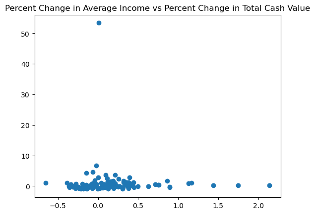

```python
plt.scatter(ag_df['Change Value'], ag_df['Change Avg Gross'])
plt.title("Percent Change in Average Income vs Percent Change in Total Cash Value")
plt.show()
```

```python
ag_df.loc[ag_df['Change Avg Gross'] == ag_df['Change Avg Gross'].max()]
```

|  | Year | State | Category | Value | Payments | Taxes | Cost Income Ratio | Liability | Labor | Avg Gross | Full Owners | Part Owners | Renters | No High School | College Graduates | Change Value | Change Avg Gross |
| --- | --- | --- | --- | --- | --- | --- | --- | --- | --- | --- | --- | --- | --- | --- | --- | --- | --- |
| 184 | 2012 | NORTH CAROLINA | Other Animals | 158365000.0 | 3700000.0 | 0.076631 | 195.9 | 1.072021 | 0.085647 | 19522.0 | 79.1 | 12.6 | 8.3 | 26.5 | 24.1 | 0.007167 | 53.399139 |

Once again, what happened in the non-cattle, hog, or poultry livestock industries in North Carolina over those five years? Let's see what the 2017 value was:

```python
survey_df.loc[(survey_df['Year'] == 2017) & (survey_df['State'] == 'NORTH CAROLINA') & (survey_df['Category'] == 'Other Animals')]
```

|  | Year | State | Category | Payments | Taxes | Cost Income Ratio | Liability | Labor | Avg Gross | Full Owners | Part Owners | Renters | No High School | College Graduates |
| --- | --- | --- | --- | --- | --- | --- | --- | --- | --- | --- | --- | --- | --- | --- |
| 289 | 2017 | NORTH CAROLINA | Other Animals | 2890000.0 | 2837.0 | 452.7 | 55366.0 | 8924.0 | 1061980.0 | 71.7 | 13.8 | 14.5 | 3.6 | 39.6 |

```python
ag_df = ag_df.drop(184)
```

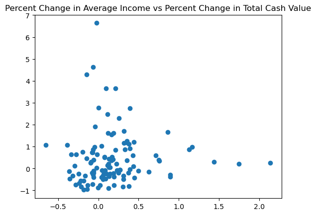

```python
plt.scatter(ag_df['Change Value'], ag_df['Change Avg Gross'])
plt.title("Percent Change in Average Income vs Percent Change in Total Cash Value")
plt.show()
```

Much better. So - these are the two values we want to predict, but before we commit to a model we should check to see if it makes any sense whatsoever given our data. Let's check how the two values correlate with the dependent variables:

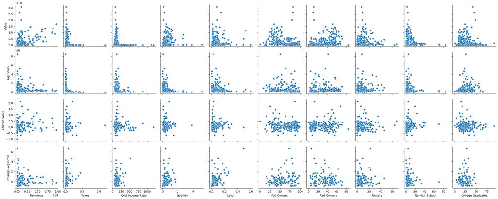

```python
sns.pairplot(data=ag_df, y_vars=['Value',
                                 'Avg Gross',
                                 'Change Value',
                                 'Change Avg Gross'],
             x_vars=['Payments',
                     'Taxes',
                     'Cost Income Ratio',
                     'Liability',
                     'Labor',
                     'Full Owners',
                     'Part Owners',
                     'Renters',
                     'No High School',
                     'College Graduates'
             ])
plt.show()
```

Some of these look ok I guess (Payments for Change in Value for example) but there's definitely a few outliers - we're going to have to keep a close eye on the accuracy of our regression. Regardless, there's not much more we can say about the data here - let's get into some modeling prep.

# First Modeling Attempt - Full Regression Models

## Model Prep

To reiterate from the intro, our goal here is to figure out what economic factors are relevant to both the overall direction of agricultural industries (in terms of raw production) and also the balance of small farm vs "Big Ag", for which we're using average gross income as a proxy (under the logic that large average income means large average farm size), so at the end of the day what I'm really interested in is the coefficients on our linear model, since those should tell us about the relative importance of the different factors found in our data.

However, this doesn't mean we don't care about accuracy: we need our regression to perform well as a way to validate the coefficients so let's get into it. First thing we need to do is standardize our data (especially important as we have a mix of units and magnitudes). We're going to use z-scoring here since its a good one size fits all approach, but we'll have to keep in mind a few limitations. Most importantly we no longer have meaningful units, so our interpretation is going to be by necessity a bit more limited.

```python
ag_df_backup = ag_df.copy() #this is a secret tool that will help us later
z_score_cols = ['Value', 'Payments', 'Taxes', 'Cost Income Ratio', 'Liability', 'Labor', 'Avg Gross', 'Full Owners', 'Part Owners', 'Renters', 'No High School', 'College Graduates']
ag_df[z_score_cols] = StandardScaler().fit_transform(ag_df[z_score_cols])
ag_df
```

|  | Year | State | Category | Value | Payments | Taxes | Cost Income Ratio | Liability | Labor | Avg Gross | Full Owners | Part Owners | Renters | No High School | College Graduates | Change Value | Change Avg Gross |
| --- | --- | --- | --- | --- | --- | --- | --- | --- | --- | --- | --- | --- | --- | --- | --- | --- | --- |
| 0 | 2007 | ARKANSAS | Cattle | -0.431702 | -0.418644 | 0.292448 | 0.570133 | 0.222597 | -0.293607 | -0.658938 | -0.155035 | 0.348599 | -0.319979 | 0.074708 | -0.663909 | 0.213337 | 3.660332 |
| 1 | 2007 | ARKANSAS | Hog | -0.565347 | -0.551378 | NaN | -0.501632 | NaN | NaN | NaN | -0.291060 | 0.747418 | -0.790922 | -0.688897 | -0.509270 | -0.483995 | NaN |
| 2 | 2007 | ARKANSAS | Oilseed and Grain | 0.000932 | 1.742955 | -0.522809 | -0.376593 | -0.687806 | -0.539475 | 0.903810 | -2.087179 | 1.006392 | 2.802939 | -0.431099 | 0.579924 | 0.893614 | -0.369125 |
| 3 | 2007 | ARKANSAS | Other Animals | -0.580956 | -0.538991 | -0.455647 | 2.177074 | -0.576878 | -0.661695 | -0.481233 | 0.854185 | -0.728731 | -0.550440 | 0.143237 | -1.363145 | 0.213666 | NaN |
| 4 | 2007 | ARKANSAS | Other Crops | -0.451526 | -0.007312 | -0.549410 | 0.099826 | -0.864527 | -0.768851 | 2.878344 | -0.793476 | -0.353219 | 2.485637 | -0.468626 | -0.028546 | -0.184644 | -0.555503 |
| ... | ... | ... | ... | ... | ... | ... | ... | ... | ... | ... | ... | ... | ... | ... | ... | ... | ... |
| 309 | 2017 | WISCONSIN | Oilseed and Grain | 0.007056 | 0.067091 | 0.259795 | -0.242857 | 0.827502 | -0.418328 | -0.535265 | -1.020916 | 1.330972 | -0.253179 | -0.352780 | -0.282915 | NaN | NaN |
| 310 | 2017 | WISCONSIN | Other Animals | -0.546716 | -0.516448 | NaN | 0.637823 | NaN | NaN | NaN | 0.389067 | -0.676936 | 0.411485 | 0.064918 | 1.299331 | NaN | NaN |
| 311 | 2017 | WISCONSIN | Other Crops | -0.531129 | -0.201453 | 4.176051 | 0.135081 | 3.900961 | 0.961925 | -0.669290 | 0.937556 | -0.816782 | -0.570480 | -0.316884 | 0.351328 | NaN | NaN |
| 312 | 2017 | WISCONSIN | Poultry | -0.455568 | -0.544108 | NaN | -0.223114 | NaN | NaN | NaN | 1.481657 | -1.345088 | -0.790922 | -0.023190 | 0.566477 | NaN | NaN |
| 313 | 2017 | WISCONSIN | Specialty Crop | -0.329673 | -0.508817 | -0.388711 | -0.327470 | -0.514393 | 0.112976 | -0.051269 | 0.033646 | -0.226322 | 0.351365 | -0.062349 | 0.687499 | NaN | NaN |

313 rows × 17 columns

No we can define our target and observed variables here before tossing them into some regression models: note that here is where we finally drop those missing values and start to get the first inklings that we might be in trouble.

```python
ag_df_clean = ag_df.dropna()
X = ag_df_clean[['Payments', 'Taxes', 'Cost Income Ratio', 'Liability', 'Labor', 'Full Owners', 'Part Owners', 'Renters', 'No High School', 'College Graduates']]
Y_total = ag_df_clean['Value']
Y_avg = ag_df_clean['Avg Gross']
y_change_total = ag_df_clean['Change Value']
y_change_avg = ag_df_clean['Change Avg Gross']
print(f"Target and independent variables defined, we dropped {ag_df.shape[0] - ag_df_clean.shape[0]} rows while doing so leaving us with a total of {ag_df_clean.shape[0]} observations.")
```

```
Target and independent variables defined, we dropped 200 rows while doing so leaving us with a total of 113 observations.
```

Losing 200 observations (the majority of our data!) is not good. Now, the easest way to see how badly this might hurt is to go ahead and try some modeling, but keep in mind that we shouldn't expecgt much running a 10 variable regression on 113 observations. Let's at least see what happens (especially since running models is pretty easy) but if this doesn't work we'll have to take a step back and be a bit more clever about which data we drop and how complex we make our models.

## Linear Regression

Caveats aside, let's go ahead and try a bog standard linear model on these ten variables. We'll define a test-train split on each target variable and then train a linear regression model from sklearn on the training set:

```python
#train total value of industry:
X_train, X_test, y_train, y_test_total = train_test_split(X, Y_total, random_state=561, test_size=.2)
total_value_model = LinearRegression()
total_value_model.fit(X_train, y_train)
total_predicted = total_value_model.predict(X_test)
#we're also going to handle the score (coefficient of prediction) and accuracy measures of each model here
total_score = total_value_model.score(X_test, y_test_total)
total_test_acc = mean_squared_error(y_test_total, total_predicted)
total_train_acc = mean_squared_error(y_train, total_value_model.predict(X_train))

#train average income:
X_train, X_test, y_train, y_test_avg = train_test_split(X, Y_avg, random_state=561, test_size=.2)
average_income_model = LinearRegression()
average_income_model.fit(X_train, y_train)
average_predicted = average_income_model.predict(X_test)
average_score = average_income_model.score(X_test, y_test_avg)
avg_test_acc = mean_squared_error(y_test_avg, average_predicted)
avg_train_acc = mean_squared_error(y_train, average_income_model.predict(X_train))

#And the change in value:
X_train, X_test, y_train, y_test_c_total = train_test_split(X, y_change_total, random_state=561, test_size=.2)
change_total_model = LinearRegression()
change_total_model.fit(X_train, y_train)
change_total_pred = average_income_model.predict(X_test)
change_value_score = change_total_model.score(X_test, y_test_c_total)
total_c_test_acc = mean_squared_error(y_test_c_total, change_total_pred)
total_c_train_acc = mean_squared_error(y_train, change_total_model.predict(X_train))

#Finally the change in income:
X_train, X_test, y_train, y_test_c_avg = train_test_split(X, y_change_avg, random_state=561, test_size=.2)
change_average_income_model = LinearRegression()
change_average_income_model.fit(X_train, y_train)
change_average_pred = change_average_income_model.predict(X_test)
change_average_score = change_average_income_model.score(X_test, y_test_c_avg)
avg_c_test_acc = mean_squared_error(y_test_c_avg, change_average_pred)
avg_c_train_acc = mean_squared_error(y_train, change_average_income_model.predict(X_train))
```

And now we can display all that model scoring information and graph the residuals:

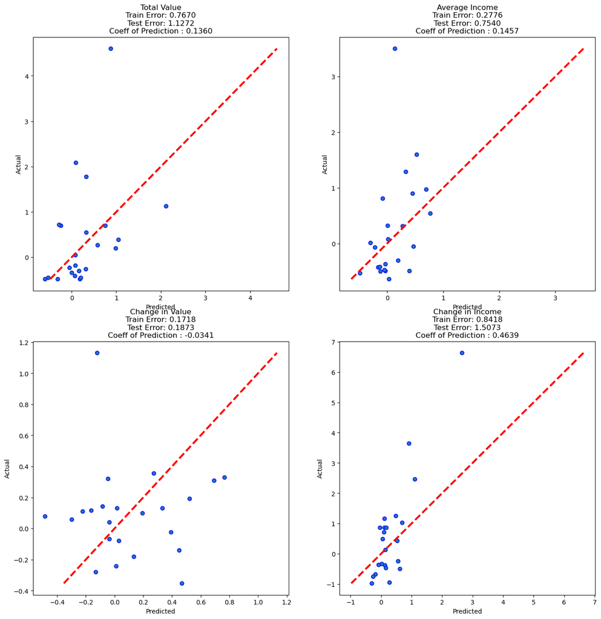

```python
#plot actual vs predicted for total value predictions
fig, ax = plt.subplots(2, 2, figsize=(16,16))
ax[0][0].scatter(total_predicted, y_test_total, edgecolors=(0, 0, 1))
ax[0][0].plot([y_test_total.min(), y_test_total.max()], [y_test_total.min(), y_test_total.max()], 'r--', lw=3)
ax[0][0].set_xlabel('Predicted')
ax[0][0].set_ylabel('Actual')
ax[0][0].set_title(f"Total Value\nTrain Error: {total_train_acc:.4f}\nTest Error: {total_test_acc:.4f}\nCoeff of Prediction : {total_score:.4f}")

#plot actual vs predicted for average income
ax[0][1].scatter(average_predicted, y_test_avg, edgecolors=(0, 0, 1))
ax[0][1].plot([y_test_avg.min(), y_test_avg.max()], [y_test_avg.min(), y_test_avg.max()], 'r--', lw=3)
ax[0][1].set_xlabel('Predicted')
ax[0][1].set_ylabel('Actual')
ax[0][1].set_title(f"Average Income\nTrain Error: {avg_train_acc:.4f}\nTest Error: {avg_test_acc:.4f}\nCoeff of Prediction : {average_score:.4f}")

#plot actual vs predicted for change in total
ax[1][0].scatter(change_total_pred, y_test_c_total, edgecolors=(0, 0, 1))
ax[1][0].plot([y_test_c_total.min(), y_test_c_total.max()], [y_test_c_total.min(), y_test_c_total.max()], 'r--', lw=3)
ax[1][0].set_xlabel('Predicted')
ax[1][0].set_ylabel('Actual')
ax[1][0].set_title(f"Change in Value\nTrain Error: {total_c_train_acc:.4f}\nTest Error: {total_c_test_acc:.4f}\nCoeff of Prediction : {change_value_score:.4f}")

#plot actual vs predicted for change in average
ax[1][1].scatter(change_average_pred, y_test_c_avg, edgecolors=(0, 0, 1))
ax[1][1].plot([y_test_c_avg.min(), y_test_c_avg.max()], [y_test_c_avg.min(), y_test_c_avg.max()], 'r--', lw=3)
ax[1][1].set_xlabel('Predicted')
ax[1][1].set_ylabel('Actual')
ax[1][1].set_title(f"Change in Income\nTrain Error: {avg_c_train_acc:.4f}\nTest Error: {avg_c_test_acc:.4f}\nCoeff of Prediction : {change_average_score:.4f}")
plt.show()
```

So overall our accuracy isn't great, but we can learn a bit more from this attempt than that. Observe the following:

- Test error is generally (except for the Change in Value model) about twice that of training error, which is symptomatic of some overfitting.
- The score on the Change in Income model may appear better than than the other models, but we can see from the high error that the model is not actually signifigantly better - this is likely a result of a particularily lucky train-test split.

Both of these, and the general variance of these models, is symptomatic of a bad fit of model hypothesis. Now, there are two possilbe reasons for this - it could be that we just dont' have data (which is the more reasonable explanation), or maybe the linear hypothesis just isn't a good one here. This is almost certainly a data problem, but let's try a non-linear model first just to check.

## Polynomial Regression

Using this method of polynomial regression also lets us easily control the degree and therefore the complexity of the hypothesis space, which is particularly important in a data poor enviroment like we're in right now. Of course, sklearn can do this more or less off the shelf:

```python
# we can use the same Xs and ys we defined for linear modeling (include as a comment here for legibility):
'''
X = ag_df[['Payments', 'Taxes', 'Cost Income Ratio', 'Liability', 'Labor', 'Full Owners', 'Part Owners', 'Renters', 'No High School', 'College Graduates']]
Y_total = ag_df['Value']
Y_avg = ag_df['Avg Gross']
y_change_total = ag_df['Change Value']
y_change_avg = ag_df['Change Avg Gross']
'''

# we're going to start with polynomial features of degree 2 and see how that does
poly_X = PolynomialFeatures(degree=2, include_bias=True)
poly_X = poly_X.fit_transform(X)
```

Once we have our new input variables, the process is identical:

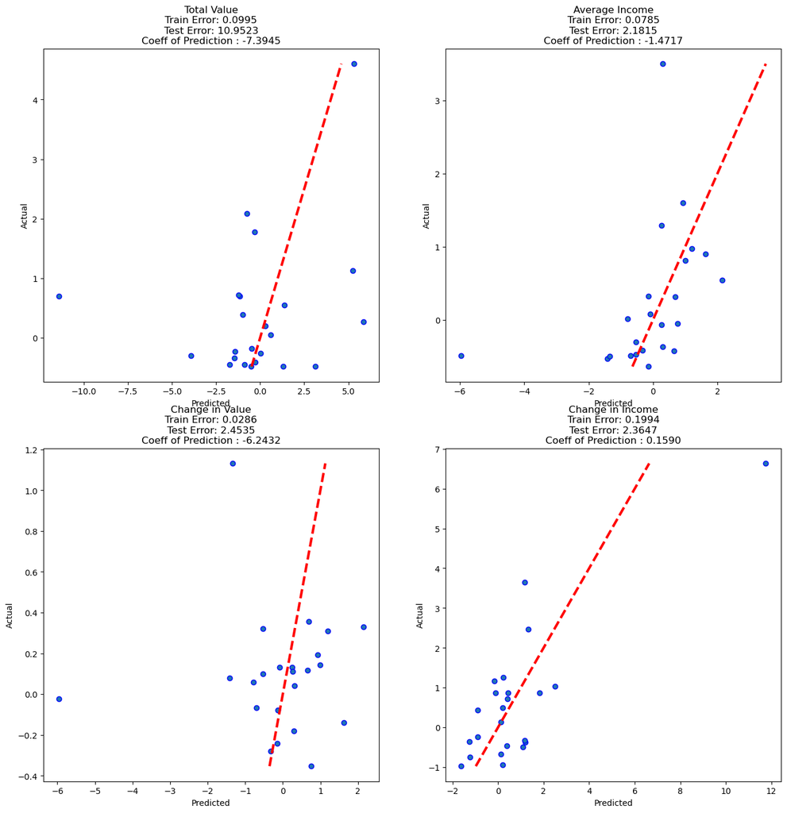

```python
#train total value of industry:
X_train, X_test, y_train, y_test_total = train_test_split(poly_X, Y_total, random_state=561, test_size=.2)
total_value_model = LinearRegression()
total_value_model.fit(X_train, y_train)
total_predicted = total_value_model.predict(X_test)
#we're also going to handle the score (coefficient of prediction) and accuracy measures of each model here
total_score = total_value_model.score(X_test, y_test_total)
total_test_acc = mean_squared_error(y_test_total, total_predicted)
total_train_acc = mean_squared_error(y_train, total_value_model.predict(X_train))

#train average income:
X_train, X_test, y_train, y_test_avg = train_test_split(poly_X, Y_avg, random_state=561, test_size=.2)
average_income_model = LinearRegression()
average_income_model.fit(X_train, y_train)
average_predicted = average_income_model.predict(X_test)
average_score = average_income_model.score(X_test, y_test_avg)
avg_test_acc = mean_squared_error(y_test_avg, average_predicted)
avg_train_acc = mean_squared_error(y_train, average_income_model.predict(X_train))

#And the change in value:
X_train, X_test, y_train, y_test_c_total = train_test_split(poly_X, y_change_total, random_state=561, test_size=.2)
change_total_model = LinearRegression()
change_total_model.fit(X_train, y_train)
change_total_pred = average_income_model.predict(X_test)
change_value_score = change_total_model.score(X_test, y_test_c_total)
total_c_test_acc = mean_squared_error(y_test_c_total, change_total_pred)
total_c_train_acc = mean_squared_error(y_train, change_total_model.predict(X_train))

#Finally the change in income:
X_train, X_test, y_train, y_test_c_avg = train_test_split(poly_X, y_change_avg, random_state=561, test_size=.2)
change_average_income_model = LinearRegression()
change_average_income_model.fit(X_train, y_train)
change_average_pred = change_average_income_model.predict(X_test)
change_average_score = change_average_income_model.score(X_test, y_test_c_avg)
avg_c_test_acc = mean_squared_error(y_test_c_avg, change_average_pred)
avg_c_train_acc = mean_squared_error(y_train, change_average_income_model.predict(X_train))


#plot actual vs predicted for total value predictions
fig, ax = plt.subplots(2, 2, figsize=(16,16))
ax[0][0].scatter(total_predicted, y_test_total, edgecolors=(0, 0, 1))
ax[0][0].plot([y_test_total.min(), y_test_total.max()], [y_test_total.min(), y_test_total.max()], 'r--', lw=3)
ax[0][0].set_xlabel('Predicted')
ax[0][0].set_ylabel('Actual')
ax[0][0].set_title(f"Total Value\nTrain Error: {total_train_acc:.4f}\nTest Error: {total_test_acc:.4f}\nCoeff of Prediction : {total_score:.4f}")

#plot actual vs predicted for average income
ax[0][1].scatter(average_predicted, y_test_avg, edgecolors=(0, 0, 1))
ax[0][1].plot([y_test_avg.min(), y_test_avg.max()], [y_test_avg.min(), y_test_avg.max()], 'r--', lw=3)
ax[0][1].set_xlabel('Predicted')
ax[0][1].set_ylabel('Actual')
ax[0][1].set_title(f"Average Income\nTrain Error: {avg_train_acc:.4f}\nTest Error: {avg_test_acc:.4f}\nCoeff of Prediction : {average_score:.4f}")

#plot actual vs predicted for change in total
ax[1][0].scatter(change_total_pred, y_test_c_total, edgecolors=(0, 0, 1))
ax[1][0].plot([y_test_c_total.min(), y_test_c_total.max()], [y_test_c_total.min(), y_test_c_total.max()], 'r--', lw=3)
ax[1][0].set_xlabel('Predicted')
ax[1][0].set_ylabel('Actual')
ax[1][0].set_title(f"Change in Value\nTrain Error: {total_c_train_acc:.4f}\nTest Error: {total_c_test_acc:.4f}\nCoeff of Prediction : {change_value_score:.4f}")

#plot actual vs predicted for change in average
ax[1][1].scatter(change_average_pred, y_test_c_avg, edgecolors=(0, 0, 1))
ax[1][1].plot([y_test_c_avg.min(), y_test_c_avg.max()], [y_test_c_avg.min(), y_test_c_avg.max()], 'r--', lw=3)
ax[1][1].set_xlabel('Predicted')
ax[1][1].set_ylabel('Actual')
ax[1][1].set_title(f"Change in Income\nTrain Error: {avg_c_train_acc:.4f}\nTest Error: {avg_c_test_acc:.4f}\nCoeff of Prediction : {change_average_score:.4f}")
plt.show()
```

Wow yeah, definitely not the solution here - we can see that the same issues we observed in the linear regression (overfitting and really crazy variance in error and coefficient of prediction) are even worse here. Clearly the lack of data is a problem, so let's try and be a little careful and see if we can get something despite the low data count.

# Second Modeling Attempt - Univariate Linear Regressions

So, we don't have the data to support the most straightforward modeling strategy i.e. throwing all our data into a sklearn model. Let's pull back a bit and just try to use each individual variable to do univariate modeling and see if we can get anything at all out of this data.

First, let's undo that z-scoring since we don't need to worry about different scales for single variable modeling, and it will be nice to have more reasonable units.

```python
ag_df = ag_df_backup # I told you this would help us later
ag_df
```

|  | Year | State | Category | Value | Payments | Taxes | Cost Income Ratio | Liability | Labor | Avg Gross | Full Owners | Part Owners | Renters | No High School | College Graduates | Change Value | Change Avg Gross |
| --- | --- | --- | --- | --- | --- | --- | --- | --- | --- | --- | --- | --- | --- | --- | --- | --- | --- |
| 0 | 2007 | ARKANSAS | Cattle | 5.969890e+08 | 23552000.0 | 0.038592 | 241.200000 | 0.732912 | 0.051651 | 2.909900e+04 | 60.300000 | 35.100000 | 4.700000 | 7.800000 | 18.300000 | 0.213337 | 3.660332 |
| 1 | 2007 | ARKANSAS | Hog | 7.903800e+07 | 0.0 | NaN | 89.200000 | NaN | NaN | NaN | 57.200000 | 42.800000 | 0.000000 | 0.000000 | 20.600000 | -0.483995 | NaN |
| 2 | 2007 | ARKANSAS | Oilseed and Grain | 2.273703e+09 | 407102000.0 | 0.001823 | 106.933333 | 0.140883 | 0.029359 | 1.578508e+06 | 16.266667 | 47.800000 | 35.866667 | 2.633333 | 36.800000 | 0.893614 | -0.369125 |
| 3 | 2007 | ARKANSAS | Other Animals | 1.854300e+07 | 2198000.0 | 0.004852 | 469.100000 | 0.213019 | 0.018277 | 2.052870e+05 | 83.300000 | 14.300000 | 2.400000 | 8.500000 | 7.900000 | 0.213666 | NaN |
| 4 | 2007 | ARKANSAS | Other Crops | 5.201590e+08 | 96538000.0 | 0.000623 | 174.500000 | 0.025963 | 0.008561 | 3.536189e+06 | 45.750000 | 21.550000 | 32.700000 | 2.250000 | 27.750000 | -0.184644 | -0.555503 |
| ... | ... | ... | ... | ... | ... | ... | ... | ... | ... | ... | ... | ... | ... | ... | ... | ... | ... |
| 309 | 2017 | WISCONSIN | Oilseed and Grain | 2.297436e+09 | 109740000.0 | 0.037120 | 125.900000 | 1.126277 | 0.040343 | 1.517163e+05 | 40.566667 | 54.066667 | 5.366667 | 3.433333 | 23.966667 | NaN | NaN |
| 310 | 2017 | WISCONSIN | Other Animals | 1.512440e+08 | 6198000.0 | NaN | 250.800000 | NaN | NaN | NaN | 72.700000 | 15.300000 | 12.000000 | 7.700000 | 47.500000 | NaN | NaN |
| 311 | 2017 | WISCONSIN | Other Crops | 2.116530e+08 | 62090000.0 | 0.213751 | 179.500000 | 3.124927 | 0.165490 | 1.883500e+04 | 85.200000 | 12.600000 | 2.200000 | 3.800000 | 33.400000 | NaN | NaN |
| 312 | 2017 | WISCONSIN | Poultry | 5.044960e+08 | 1290000.0 | NaN | 128.700000 | NaN | NaN | NaN | 97.600000 | 2.400000 | 0.000000 | 6.800000 | 36.600000 | NaN | NaN |
| 313 | 2017 | WISCONSIN | Specialty Crop | 9.924110e+08 | 7552000.0 | 0.007871 | 113.900000 | 0.253652 | 0.088516 | 6.315810e+05 | 64.600000 | 24.000000 | 11.400000 | 6.400000 | 38.400000 | NaN | NaN |

Now we could use sklearn to do all these models, but like any good programmer I'm going to borrow some code that already does this job (of running and comparing linear regressions on a bunch of single variables) from Dr. Nick Mattei (code taken from [this notebook](https://github.com/nmattei/cmps6790/blob/main/_demos/Demo-10.ipynb)) and making some small modifications - no need to reinvent the wheel. This also lets us look at how a different python library handles this sort of modeling since we'll be using scipy rather than sklearn.

```python
def regress_with_stats(df, observations, target):
  fig, ax = plt.subplots(1, len(observations), figsize=(24,8), sharex=False)

  for i,o in enumerate(observations):
      temp_df = df[[target, o]].dropna()
      slope, intercept, r_value, p_value, std_err = stats.linregress(temp_df[o],
                                                                     temp_df[target])
      # Pack these into a nice title
      diag_str = "p-value=%.1g\nr-value=%.3f\nstd err.=%.3f\nslope=%.3f\nintercept=%.3f" % (p_value, r_value, std_err, slope, intercept)
      temp_df.plot.scatter(x=o, y=target, title=diag_str, ax=ax[i])
      y_pred = df[o] * slope + intercept
      # Make points and line
      pts = np.linspace(temp_df[o].min(), temp_df[o].max(), 500)
      line = slope * pts + intercept
      ax[i].plot(pts, line, lw=1, color='red')
```

Alright with that function stolen/defined/modified, we can get to regressing. This is going to be a lot of graphs, so I'll break them up by target variable. In each section we'll do two batches of graphs - one for money based data (government payments, debt, etc) and one for info about farmers (how many rent, level of education, etc). If you don't want to look at all the graphs (and who could blame you) I recommend checking out the models for Total Industry Value and Change in Average Income, which I think present the most interesting results.

### Total Industry Value:

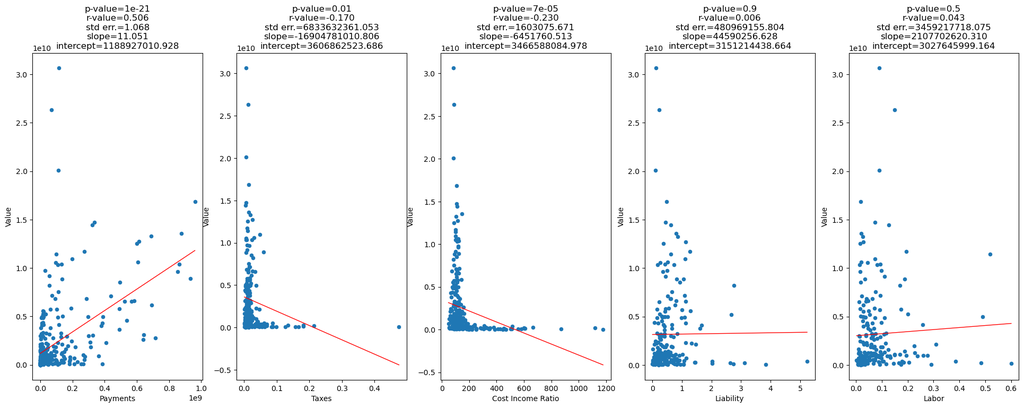

```python
regress_with_stats(ag_df, ['Payments', 'Taxes', 'Cost Income Ratio', 'Liability', 'Labor'], 'Value')
```

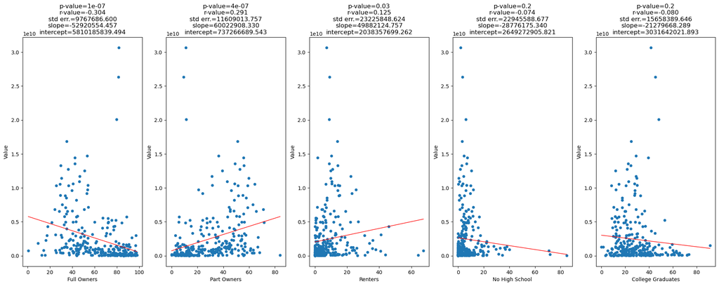

```python
regress_with_stats(ag_df, ['Full Owners', 'Part Owners', 'Renters', 'No High School', 'College Graduates'], 'Value')
```

No amazing surprises here - but we do have some good results on Full Owners and Part Owners. It seems that the more farmers own their whole farm the lower the total value of the industry tends to be. The intial intuitive hypothesis here would probably be something about how larger, more profitable industries tend to be run centrally by agricultural corporations leading to fewer full owners in those industries. We see a similar pattern, though a little less well founded, in Renter rates. Unfortunately education level doesn't seem to be hugely influential here.

### Avg Farm Income

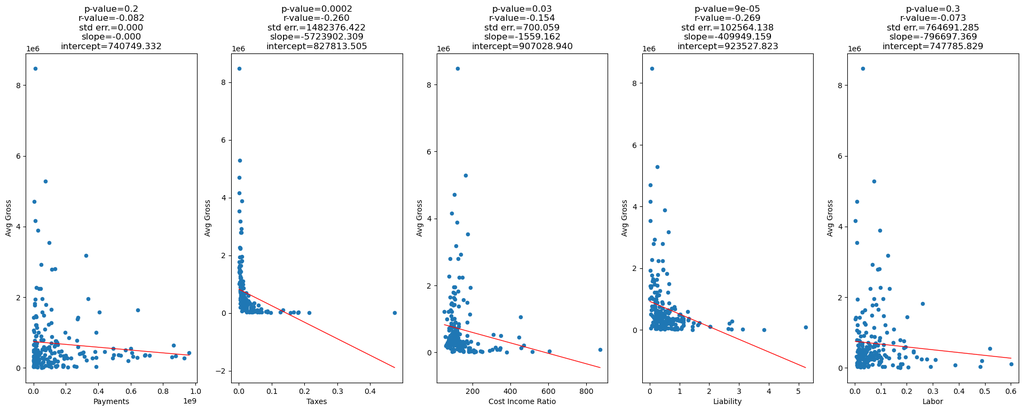

```python
regress_with_stats(ag_df, ['Payments', 'Taxes', 'Cost Income Ratio', 'Liability', 'Labor'], 'Avg Gross')
```

These are mostly total pap - again we see a few decent p-values on Taxes, Cost Income Ratio and Liability, but the distribution of that data makes it fairly clear we're not really picking up on much.

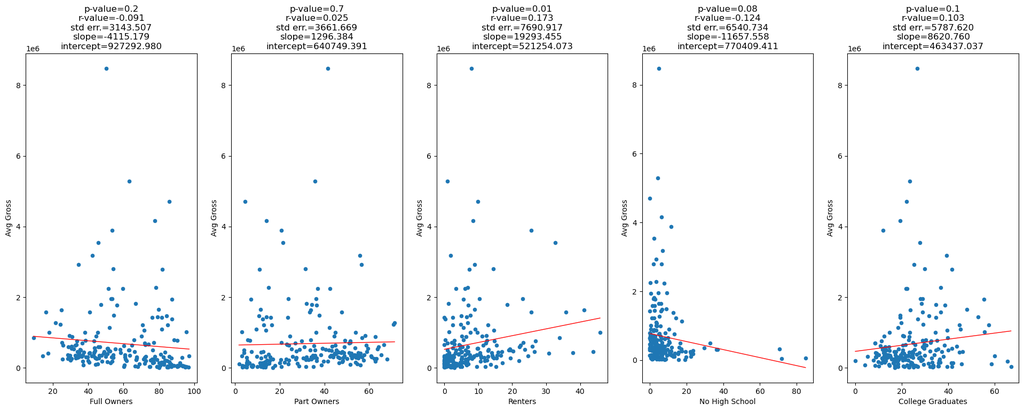

```python
regress_with_stats(ag_df, ['Full Owners', 'Part Owners', 'Renters', 'No High School', 'College Graduates'], 'Avg Gross')
```

A little better here, but I think we're mostly just picking up on the same trends as we found on total value modeling. The regression for College Graduates (recall, the % of operators who have a college degree) is decent here, and actually reverses the trend from Total Value, in that it appears educated operators have higher average farm incomes - not groundbreaking but good to see.

### Change in Total Value

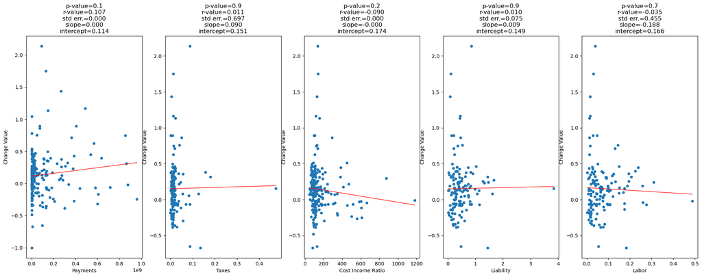

```python
regress_with_stats(ag_df, ['Payments', 'Taxes', 'Cost Income Ratio', 'Liability', 'Labor'], 'Change Value')
```

Absolutely nothing of interest in these models.

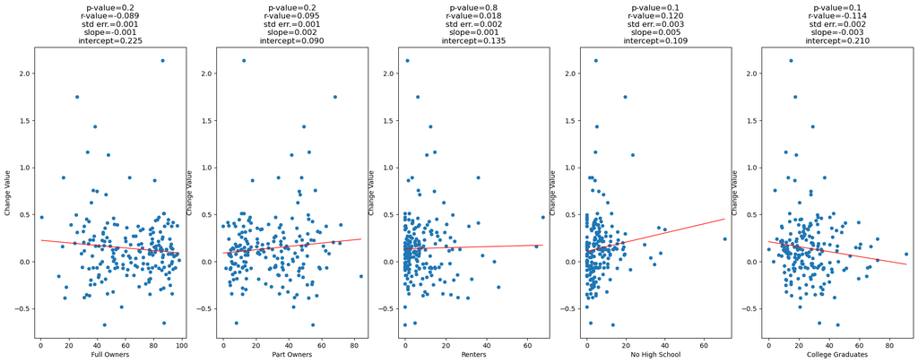

```python
regress_with_stats(ag_df, ['Full Owners', 'Part Owners', 'Renters', 'No High School', 'College Graduates'], 'Change Value')
```

Again, not much going on here - predicting changes in value seems to generally be much more difficult than just predicting values. We do have a not-unreasonble model based on College Graduation rates, which oddly predicts lower growth rates. That may just be an artifact of how few highly college educated industries we have in our data - even if the idea of over-educated hipster farmers not growing their businesses as fast is attractive.

### Change in Average Income

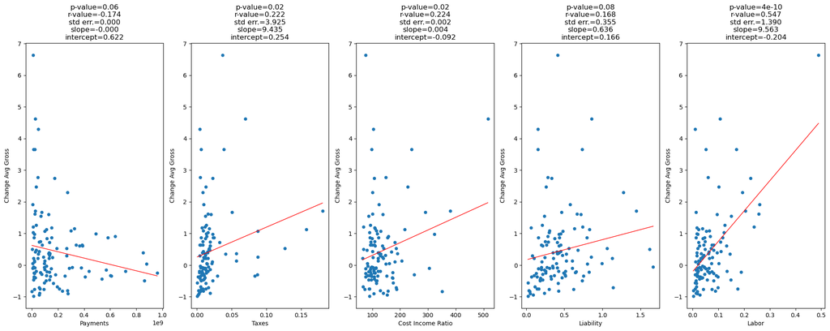

```python
regress_with_stats(ag_df, ['Payments', 'Taxes', 'Cost Income Ratio', 'Liability', 'Labor'], 'Change Avg Gross')
```

These are interesting regressions but also a bit weird - there's definitely some clustering going on on the lower end of a lot of these. I think the most interesting is that it appears we have a real relationship between labor costs (recall this is a ratio between labor and average income) and growth, in that the more farms tend to spend on labor relative to their income the better the average farm tends to do over the next five years.

This is particularily interesting given that we have no such relationship between labor costs and change in total value - only for higher average value. I don't really have a just-so story for this so I think this is a genuienly interesting finding, and could be a cool effect to verify and chase down with more/different data.

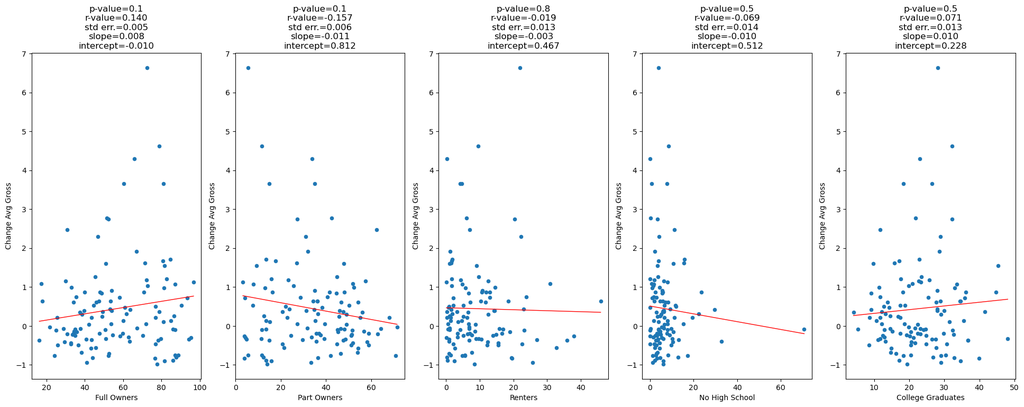

```python
regress_with_stats(ag_df, ['Full Owners', 'Part Owners', 'Renters', 'No High School', 'College Graduates'], 'Change Avg Gross')
```

Unfortunately the results for the demographic data here are less conclusive - some incredibly mild effect from higher levels of ownership but nothing all that signifigant.

# Conclusions

## Takeaways

So, what did we learn through our two passes at modeling/analyzing this data? Well on the data science best practices/meta side I think there's one major takeaway from each of the two modeling attempts:

1. We - specifically because of ARMS - do not have complete enough data to do even moderately complicated modeling, so attempting to take the easy way out and just toss all the data into an sklearn model went nowhere.
2. There are some genuine trends and correlations within the data we do have, even if there are only a few such variables.